# Visualización

### Variables continuas

Si deseamos explorar las distribuciones de las variables podemos optar por un histograma.

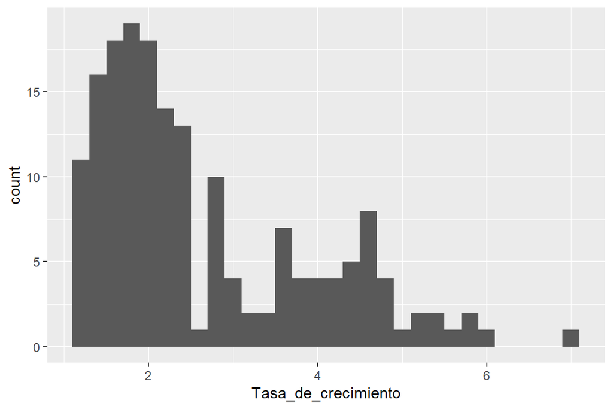

```r
ggplot(paises, aes(Tasa_de_crecimiento)) +
               geom_histogram()
```

Se puede cambiar la apariencia para una mejor visualización.

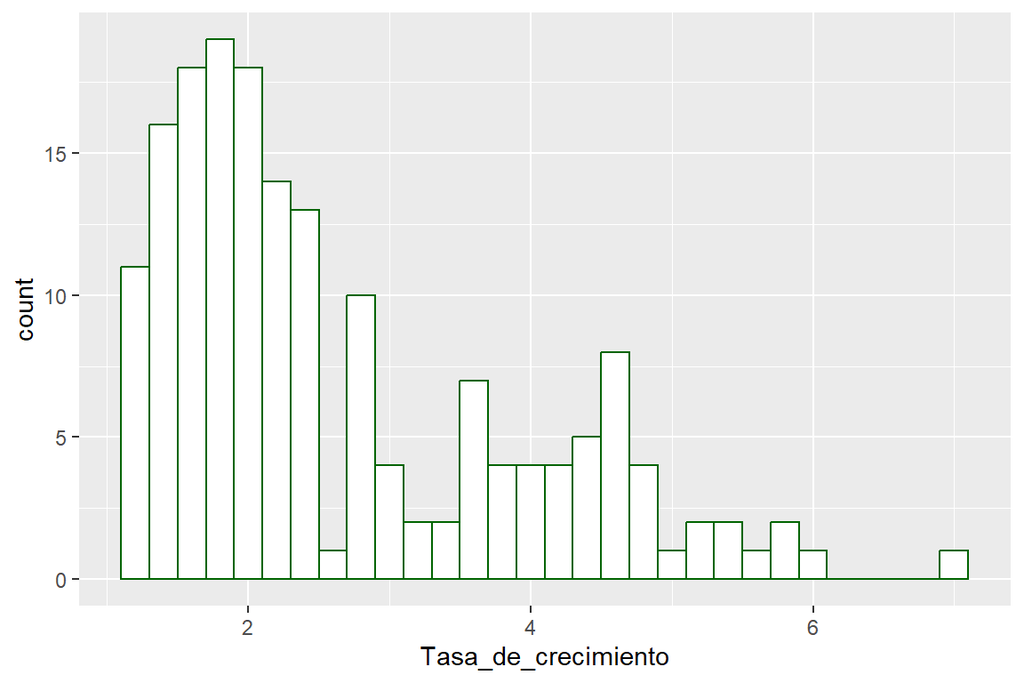

```r
ggplot(paises, aes(Tasa_de_crecimiento)) +
               geom_histogram(colour = "darkgreen", fill = "white")
```

Además, en un mismo histograma se puede diferenciar por los niveles de otro factor. También se pueden dibujar las densidades

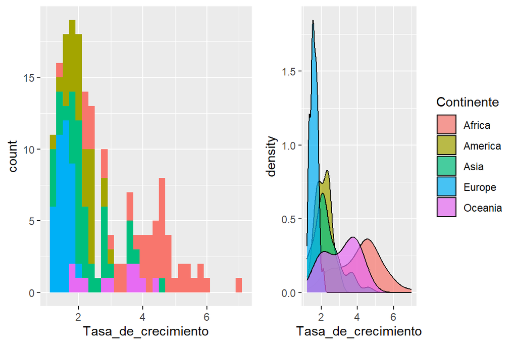

```r
cowplot::plot_grid(

ggplot(paises, aes(Tasa_de_crecimiento, fill = Continente)) +
               geom_histogram()+
               guides(fill=FALSE)
,
ggplot(paises, aes(Tasa_de_crecimiento, fill = Continente)) +
               geom_density(alpha=0.7)
,
align="h"
)
```

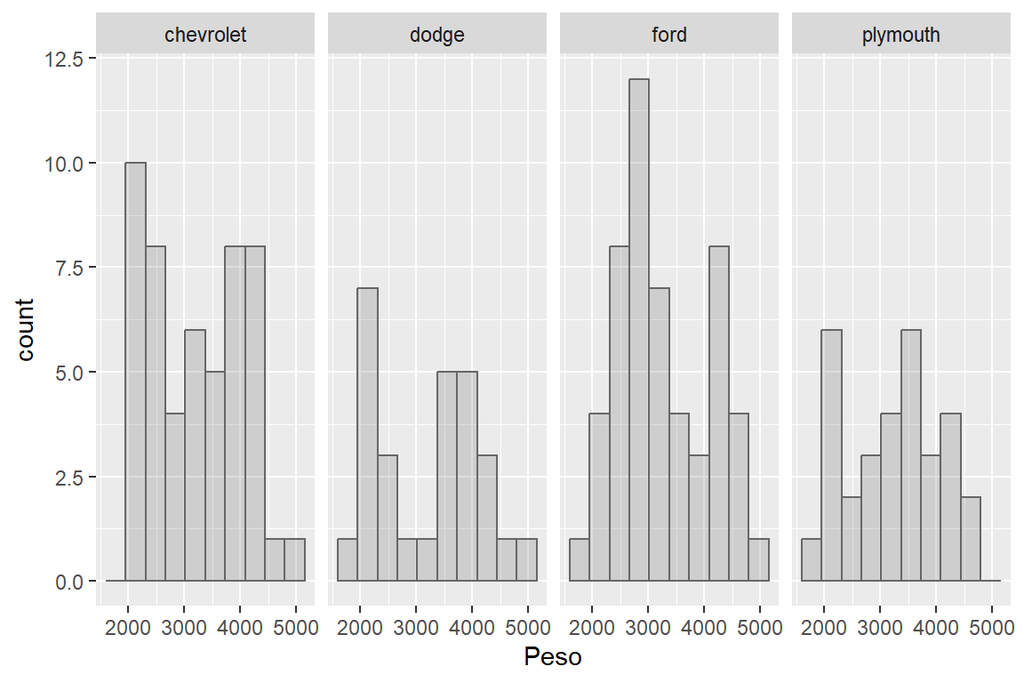

```r
ggplot(autos, aes(Peso)) +
    geom_histogram(position="identity", colour="grey40", alpha=0.2, bins = 10) +
    facet_grid(. ~ Marca)
```

También se puede utilizar **facet_grid** con dos variables categóricas

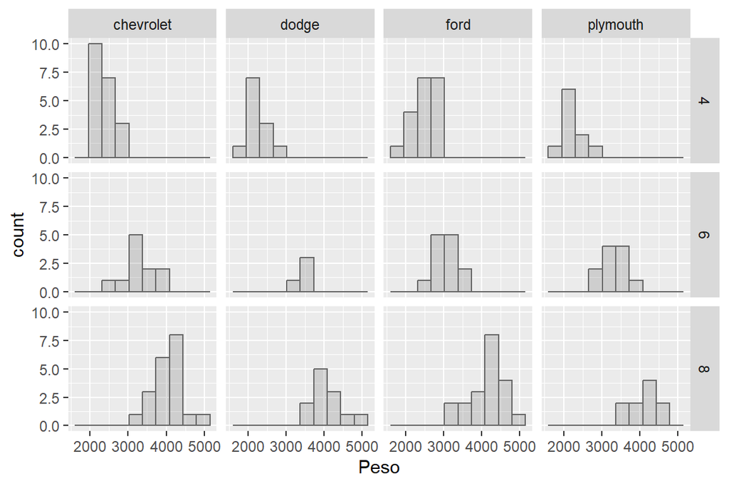

```r
ggplot(autos, aes(Peso)) +
    geom_histogram(position="identity", colour="grey40", alpha=0.2, bins = 10) +
    facet_grid(Cilindrada ~ Marca)
```

- Gráficos de boxplot

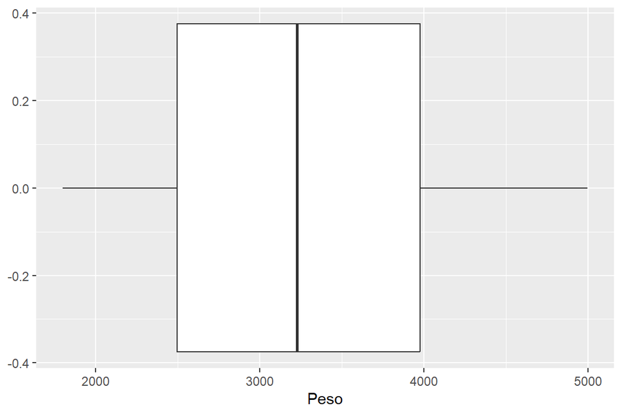

```r
ggplot(autos, aes(Peso)) +
    geom_boxplot()
```

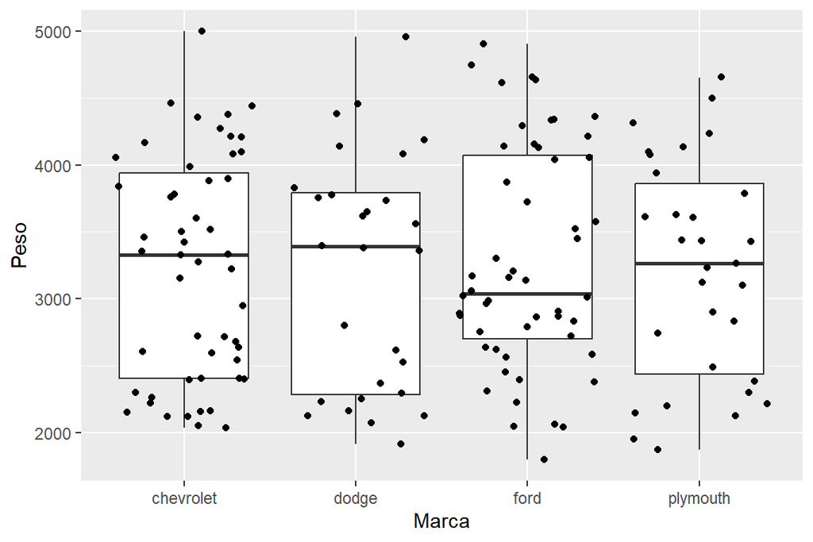

```r
ggplot(autos, aes(x=Marca, y=Peso)) +
    geom_boxplot() + geom_jitter()
```

```r
head(autos)
```

|  | Rendimiento.(millas.por.galon) | Cilindrada | HP | Peso | Aceleracion | Modelo | Marca | X8 |
| --- | --- | --- | --- | --- | --- | --- | --- | --- |
| 1 | 18 | 8 | 130 | 3504 | 12.0 | 70 | chevrolet | NA |
| 2 | 14 | 8 | 220 | 4354 | 9.0 | 70 | chevrolet | NA |
| 3 | 15 | 8 | 150 | 3761 | 9.5 | 70 | chevrolet | NA |
| 4 | 10 | 8 | 200 | 4376 | 15.0 | 70 | chevrolet | NA |
| 5 | 28 | 4 | 90 | 2264 | 15.5 | 71 | chevrolet | NA |
| 6 | 17 | 6 | 100 | 3329 | 15.5 | 71 | chevrolet | NA |

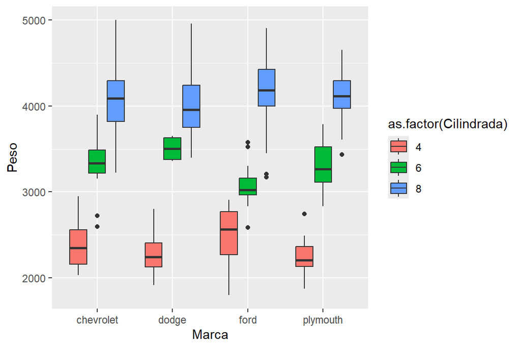

```r
ggplot(autos, aes(x=Marca, y=Peso, fill=as.factor(Cilindrada))) +
    geom_boxplot()
```

### Visualización de la matriz de correlaciones

```r
library(ggcorrplot)
var_corr_autos <- autos %>% select("Rendimiento.(millas.por.galon)",
                                   "HP", "Peso", "Aceleracion")
head(var_corr_autos)
```

|  | Rendimiento.(millas.por.galon) | HP | Peso | Aceleracion |
| --- | --- | --- | --- | --- |
| 1 | 18 | 130 | 3504 | 12.0 |
| 2 | 14 | 220 | 4354 | 9.0 |
| 3 | 15 | 150 | 3761 | 9.5 |
| 4 | 10 | 200 | 4376 | 15.0 |
| 5 | 28 | 90 | 2264 | 15.5 |
| 6 | 17 | 100 | 3329 | 15.5 |

```r
corr_autos <- round(cor(var_corr_autos), 2)
corr_autos
```

```
##                                Rendimiento.(millas.por.galon)    HP  Peso Aceleracion
## Rendimiento.(millas.por.galon)                           1.00 -0.79 -0.88        0.35
## HP                                                      -0.79  1.00  0.87       -0.69
## Peso                                                    -0.88  0.87  1.00       -0.46
## Aceleracion                                              0.35 -0.69 -0.46        1.00
```

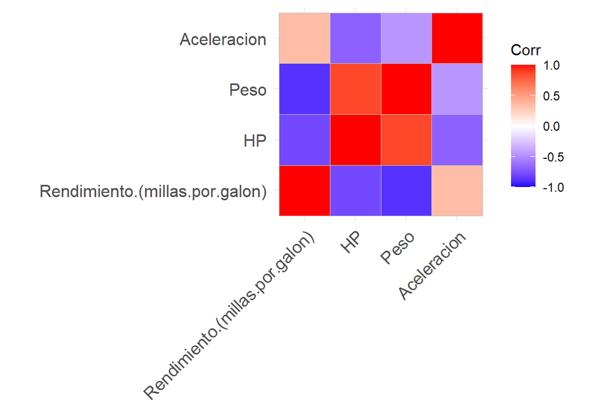

```r
ggcorrplot(corr_autos)
```

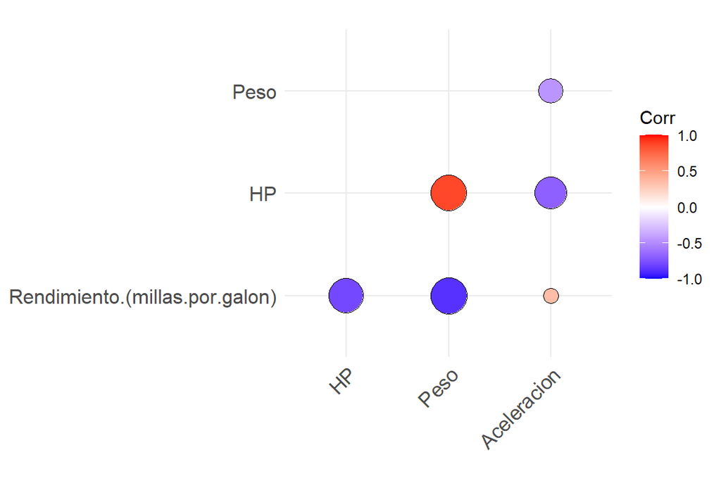

```r
ggcorrplot(cor(var_corr_autos),
 method = "circle",
 type = "lower",
 outline.color = "black",
 lab_size = 6)
```

[Galería de gráficos para representar a la matriz de correlación](https://rpubs.com/Alema/1000474)

## Heatmap

Un mapa de calor es una representación gráfica de datos que muestra la intensidad relativa de los valores en una matriz mediante colores. Se utiliza comúnmente para visualizar conjuntos de datos complejos e identificar patrones, correlaciones y valores atípicos. Los mapas de calor son especialmente útiles al trabajar con grandes conjuntos de datos o datos con alta dimensionalidad. Ofrecen una visión general de los datos.

En R, se pueden crear mapas de calor mediante la función **heatmap()**, que toma una matriz o un marco de datos como entrada y genera un gráfico con la intensidad relativa de los valores, representada en colores

Como ejemplo vamos a utilizar una base de datos que contiene nombres de personas utilizados en Argentina desde 1922 hasta 2015

```r
nombres_arg <- read.csv("Bases de datos/historico-nombres.csv")
nombres_arg %>% head()
```

|  | X | nombre | cantidad | anio |
| --- | --- | --- | --- | --- |
| 1 | 1 | Maria | 314 | 1922 |
| 2 | 2 | Rosa | 203 | 1922 |
| 3 | 3 | Jose | 163 | 1922 |
| 4 | 4 | Maria Luisa | 127 | 1922 |
| 5 | 5 | Carmen | 117 | 1922 |
| 6 | 6 | Ana | 113 | 1922 |

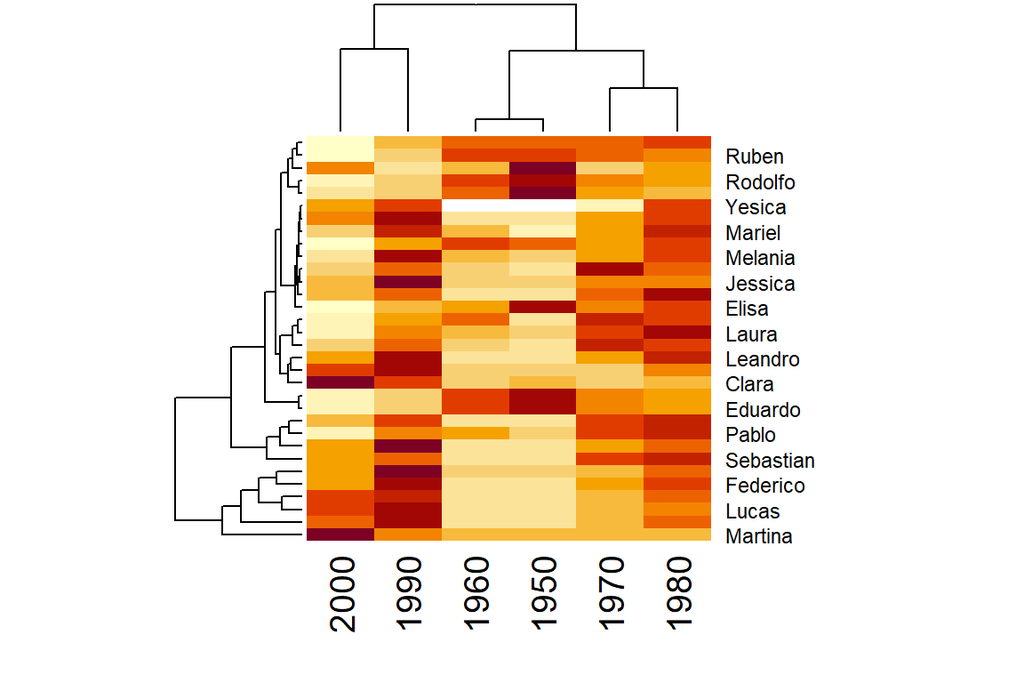

```r
df_graficar_anio <- nombres_arg %>%
  filter(
    nombre %in% c("Clara", "Rodrigo", "Lucas", "Jessica", "Guillermo",
                  "Ana", "Ruben", "Erika", "Sebastian", "Federico",
                  "Alejandra", "Elsa", "Nicolas", "Florencia", "Laura",
                  "Rodolfo", "Eduardo", "Mariel", "Mariano", "Elisa",
                  "Nahuel", "Pablo", "Leandro", "Federico", "Yesica", "Christian",
                  "Carlos", "Leticia", "Matias", "Melania", "Jesus", "Martina", "Diego"),
    anio >= 1950,
    anio <  2010
  ) %>%
  select(-X) %>%
  mutate(decada = anio %/% 10 * 10)

df_graficar_decada <- df_graficar_anio %>%
  select(-anio) %>%
  group_by(nombre, decada) %>%
  summarise(cantidad = sum(cantidad))

nombres <- df_graficar_decada %>%
  pivot_wider(names_from = decada, values_from = cantidad)

nombres <- as.data.frame(nombres)
rownames(nombres) <- nombres$nombre
nombres <- nombres[-1]
nombres <- as.matrix(nombres)

heatmap(nombres)
```

Se le puede quitar los dendogramas

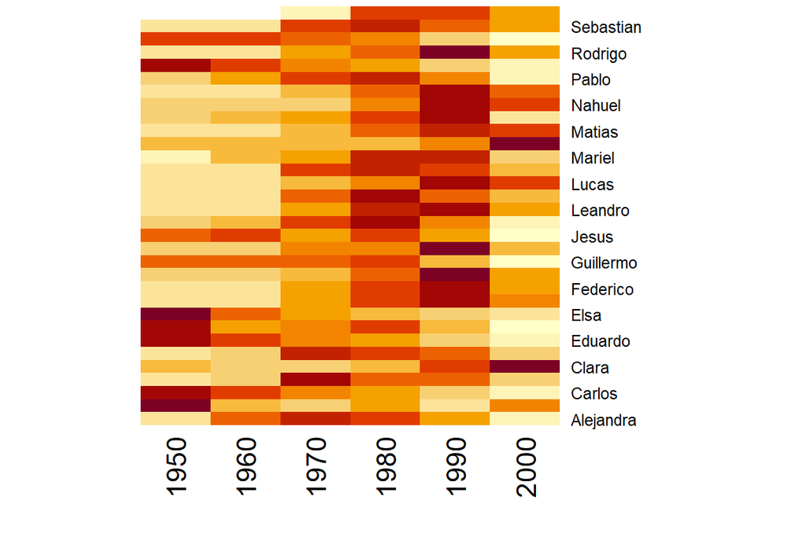

```r
heatmap(nombres, Rowv = NA, Colv = NA)
```

Se puede cambiar la paleta de colores

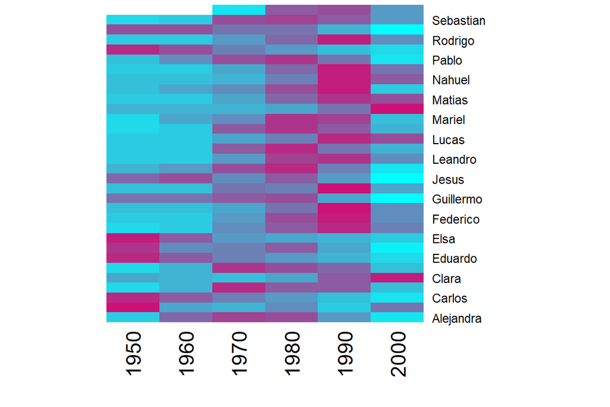

```r
mis_colores<- colorRampPalette(c("cyan", "deeppink3"))
heatmap(nombres, Rowv = NA, Colv = NA, col = mis_colores(20))
```

- [Galería con posibles gráficos de heatmap](https://r--graph--gallery-com.translate.goog/heatmap?_x_tr_sl=en&_x_tr_tl=es&_x_tr_hl=es&_x_tr_pto=tc)

## Ejercicios

Instalar la librería **dslabs** y cargar la base de datos “gapminder” contenida dentro de esta librería con la función ‘data()’.

A partir de esta base de datos responder resolver los siguiente ítems:

1. Realizar un diagrama de dispersión para el año 1960 entre las variables fertilidad y expectativa de vida, y agregarle una línea de tendencia.
2. Realizar el diagrama del punto 1 por continente y comparar.
3. Comparar, en un mismo gráfico, la expectativa de vida entre Argentina y España desde 1960 hasta 2015.
4. A partir de boxplot comparar la poblaciones de los diferentes continentes para el para los años 1980 y 2015.
5. Utilizando la función **facet_grid**, y graficando histogramas, hacer una comparación del ingreso percápita de cada continente desde el año 2010 hasta el año 2015.
6. ¿Qué continente tiene mayor tasa de mortalidad infantil promedio a lo largo de los años?
7. Escribir el código correspondiente para realizar el siguiente gráfico:

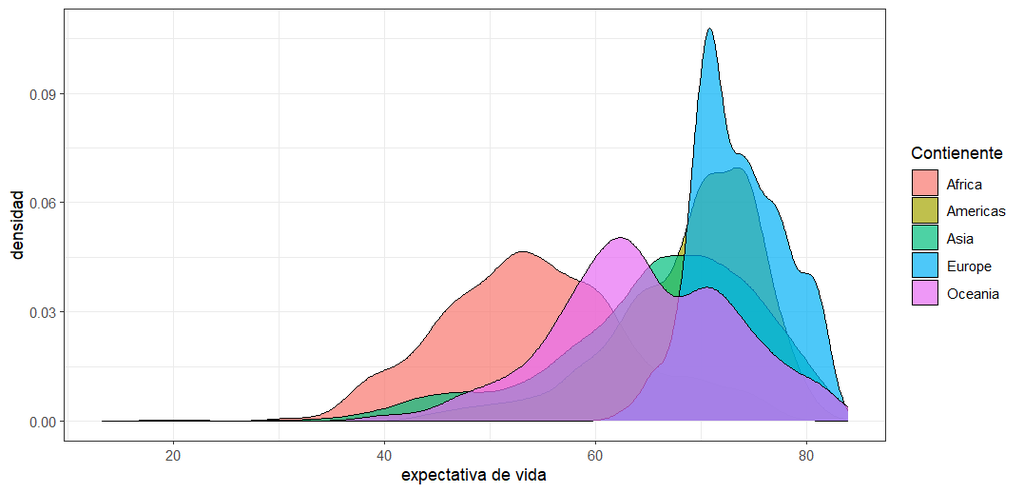